# Individual-based Integral Projection Models: The role of size-structure on extinction risk and establishment success

### Numerically Implementing and Utilizing $\Psi$

For the previously described methods to work, it is critical that column sums for growth and the sum of offspring size distribution vector equal one i.e. the columns are probability vectors. For most IPMs, this will not occur automatically due to individuals being evicted from the size interval $[\alpha,\beta]$. There are a variety of ways to handle this issue (Ref). As the offspring size vectors nearly summed to one, we simply renormalized it so that it summed to one. For the growth matrix, we treated eviction as mortality to be consistent with the model developed by Nicoles et al. To do this, we took one minus the column sums and substracted them from the survival vector and then normalized the column sums so that they added to one. When taking the product of survival and growth, the mean-field IPM is unaffected by this change.

Using these discretized demographic components and the pgf $\phi$ for fecunidy, we get the discretized pgf $\Psi$ is given by $\Psi_{discrete}(h)=s.vec\circ (g.mat^T\, h)+1-s.vec)\circ(1-p.vec+p.vec\circ phi(xs,e.vec^T\,h))$ where $h$ corresponds to a discretized function i.e. a vector of length $n$, $^T$ denotes the transpose of a matrix or vector, and $\circ$ denotes element by element multiplication.

```r
n=100 # number of bins
xs=seq(alpha,2*beta,length=n)
dx=xs[2]-xs[1]
s.vec=s(xs)*0.95
e.vec=e(xs)*dx
flowering.vec=as.numeric(flowering(xs))
e.vec=e.vec/sum(e.vec)
g.mat=outer(xs,xs,g)*dx
q.evict=1-colSums(g.mat)
g.mat=g.mat%*%diag(1/(1-q.evict))
# Note: most of the eviction is from negative sized individuals
s.vec=(1-q.evict)*s.vec
phi=function(x,s)exp(f(x)*(s-1))
Psi=function(h){
    h.new=(s.vec*(t(g.mat)%*%h)+1-s.vec)*(1-flowering.vec+flowering.vec*phi(xs,e.vec%*%h))
    return(h.new)
}
Psi.iterate=function(T){
    hs=matrix(0,T+1,n)
    for(t in 1:T){
        hs[t+1,]=Psi(hs[t,])
        }
    return(hs)
}

# function for estimating asymptotic extinction probability
AE=function(tol=0.0001){
  h=rep(0,n)
  diff=1
  while(diff>tol){
    h.old=h
    h=Psi(h)
    diff=sum(abs(h.old-h))
  }
  return(h)
}
```

The figure below illustrates how extinction probabilities $E_t(x)$ vary with size over a $100$ year time frame. Intuitively, this figure illustrates that the probability of extinction decreases with the size of individual initially founding the population, and extinction probabilities increase over time. Furthermore, this figure illustrates that $E_t(x)$ are approaching limiting extinction probabilities $E_{\infy}(x)$ which are less than one. This stems from the fact that the dominant eigenvalue of the mean-field IPM is greater than one. To estimate this asymptotic probability of extinction one can iterate $\Psi$ until a tolerance condition is met e.g. $|E_{t+1}(x)-E_t(x)|\le \epsilon$ for all $x$.

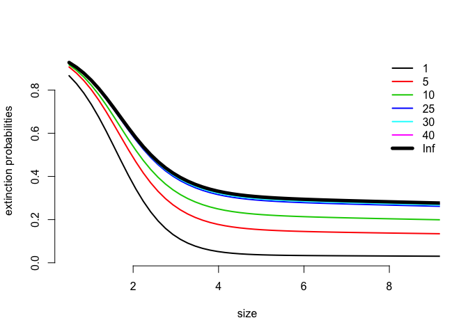

```r
T=100
out=Psi.iterate(T)
times=c(1,5,10,25,30,40)+1
matplot(xs,t(out[times,]),xlim=c(alpha,beta),type="l",lty=1,xlab="size",ylab="extinction probabilities",bty="n",lwd=2)
legend("topright",c(as.character(times-1),expression(Inf)),col=c(1:length(times),"black"),lty=1,lwd=c(rep(2,length(times)),5),bty="n")
# adding the asymptotic extinction probability
h=AE()
lines(xs,h,type="l",xlab="size",ylab="asymptotic extinction probability",lwd=5,xlim=c(alpha,beta))
```

Alternatively, we can use the actual population data from 2001 to see how extinction risk over different time frames, $5$ or $50$ years, depends on the size of a random subpopulation. This figure illustrates that $\log$ extinction risk decreases linearly with population size where the variation around this mean trend stems from the random sampling of individuals.

```r
#Inputs: N vector of length $n$ which specifies the initial number of individuals in each size bin, and T the length of the time to look things over.
#Output:a vector of length T+1 corresponding to the probabilities of extinction by time t or sooner
PVA=function(N,T){
    hs=Psi.iterate(T)
    output=numeric(T+1)
    for(t in 1:(T+1)){
        output[t]=prod(hs[t,]^N)
    }
    return(output)
}
```

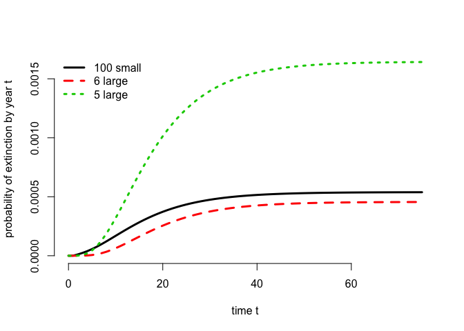

```r
T=75
N=rep(0,n)
N[1]=100
out1=PVA(N,T)
N=rep(0,n)
N[50]=6
out2=PVA(N,T)
N=rep(0,n)
N[50]=5
out3=PVA(N,T)
out=cbind(out1,out2,out3)
matplot(0:T,out,typ="l",lwd=3,bty="n",xlab="time t",ylab="probability of extinction by year t")
legend("topleft",c("100 small","6 large","5 large"),lty=1:3,col=1:3,lwd=3,bty="n")
```

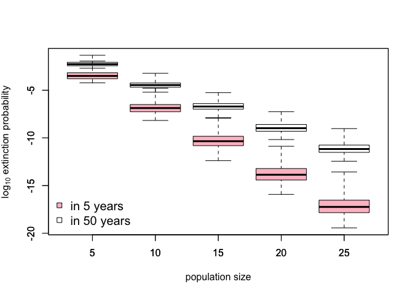

```r
sizes=data$size[1:400] # empirical data
T=51
T2=5
sample.sizes=5*(1:5)
no.samples=500
stuff=c()
stuff2=c()
temp=numeric(no.samples)
temp2=temp
for(j in 1:length(sample.sizes)){
for(i in 1:no.samples){
sampling=sample(sizes,size=sample.sizes[j])
out2=hist(sampling,breaks=xs,plot=FALSE)
N=c(0,out2$counts)
out=PVA(N,T)
temp[i]=out[T+1]
temp2[i]=out[T2+1]
}
stuff=cbind(stuff,temp)
stuff2=cbind(stuff2,temp2)
}
boxplot(log10(stuff),notch=FALSE,names=sample.sizes,col="white",range=0,xlab="population size",ylab=expression(paste(log[10]," extinction probability")),ylim=c(min(log10(stuff2)),max(log10(stuff))))
boxplot(log10(stuff2),notch=FALSE,names=sample.sizes,col="pink",range=0,add=TRUE)
legend("bottomleft",c("in 5 years","in 50 years"),pch=22,pt.bg=c("pink","white"),cex=1.25,bty="n")
```

## Extra stuff

### Sensitivity Formulas

**I corrected the formula below, but it will be much harder to explain and illustrate how to generally implement. Consequently, I am planning on removing this section**

To examine the sensitivity of the extinction probability $E_t(x)$ to a parameter $\alpha$ in an individual-based IPM such as the slope or intercept of the logistic regression for a survival function, the chain rule implies that $\frac{\partial E_{t+1} }{\partial \alpha}(x)=\frac{\partial\Psi}{\partial \alpha}(E_t)(x)+\frac{\partial \Psi}{\partial h}(E_t)(x)\frac{\partial E_t}{\partial \alpha}(x)$ We can use this equation to inductively find these sensitivities as $\frac{\partial E_0}{\partial \alpha}(x)=0$ for all $x$.